# Part II - (Loan Data From Prosper)

## by (MURHULA BYABUSHI CHRISTIAN)

## Investigation Overview

In this investigation, i wanted to analyse the elements that influence the loan and borrows, by interpreting technically some variables.

## Dataset Overview

Prosper-Loan dataset contains 113937 entries of loan with113,937 loans with 81 variables on each loan, including loan amount, borrower rate (or interest rate), current loan status, borrower income, and many others.

## How is the borrower rate interest ?

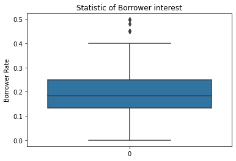

his chart shows us that the lowest borrow rate is 0%, the common is around 0.2, and the highest is 0.4. But some loans pay more than that as the points out of the the max value of the plot shows.

### How is statitic of general payment reliazed for each loan status?

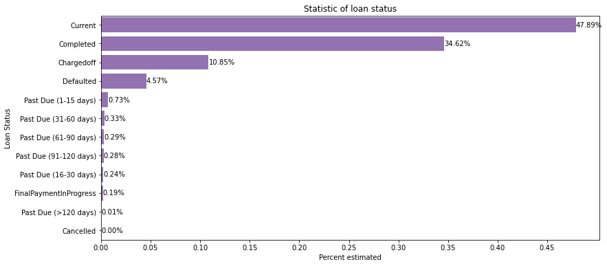

### How is the the correlation between the loan amount and the borrower interest rate ?

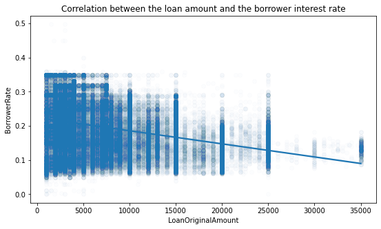

This plot shows that the loaOriginalAMount when increases, the Borrowerate decreases. The coorelation between both is negative.

### Whitch loan amount every listing category has accumulated ?

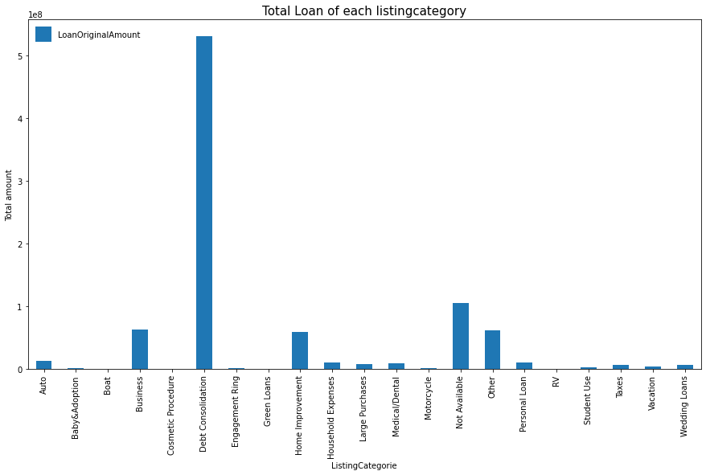

### How is the coorelation between numerical variables inside of the data?

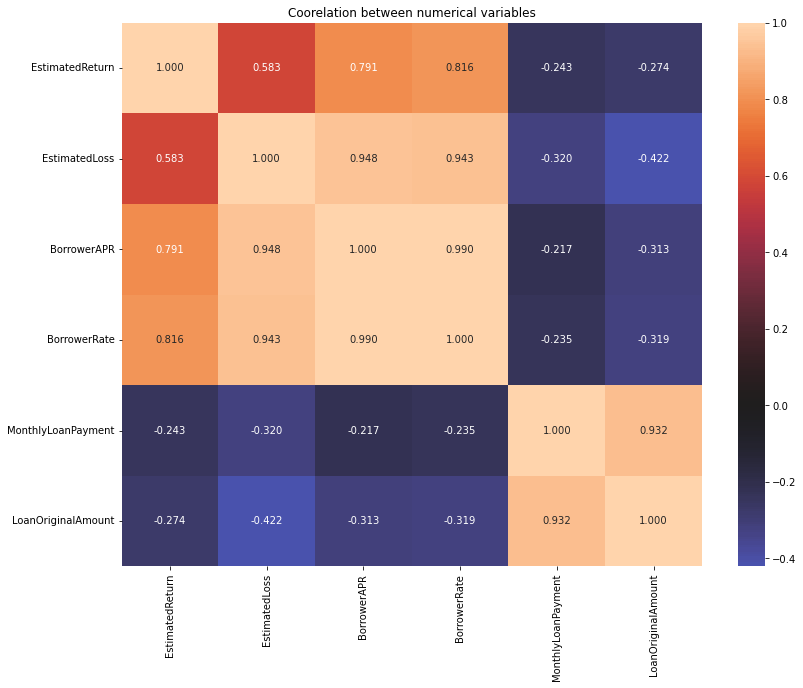

This plot shows that the LoanOriginalAmount with even the borrower rate nor borrowerAPR is negative, estimated at -0.3. This means as the LoanOrignalAmount increases, the BorrowerRate decreases.

### What is the duration of the loan offered by borrowers according to their status ?

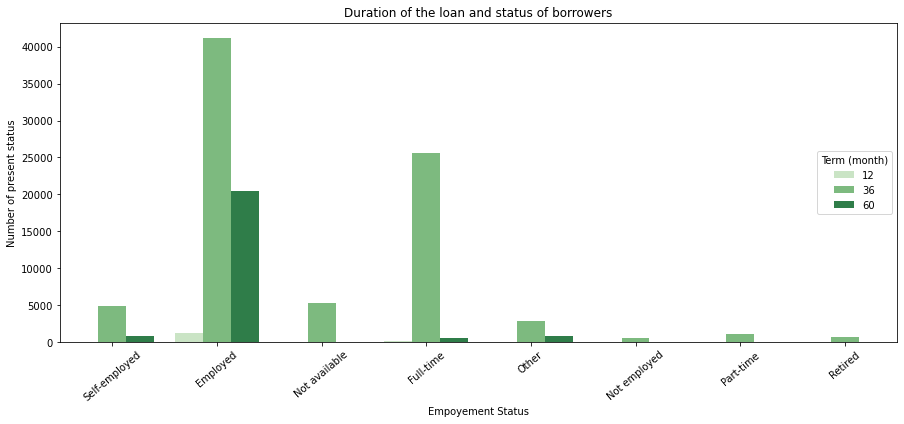

The graph shows that borrowers who are salaried most often grant the loan estimated at 36 and 60 for the others.

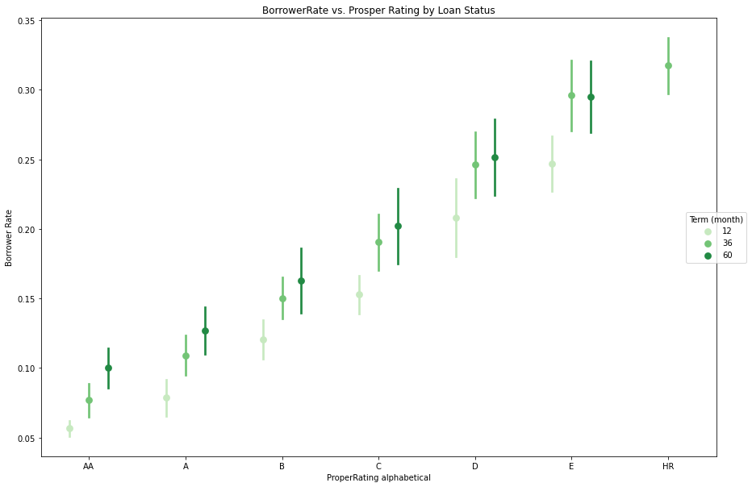

This graph shows that the standard deviation of each properRating depends each one during a all terms represented(12,36 and 60 months). Obsiouly the properrating with HR return a higher rate interest.